# Network analysis with sparCC

Anders K. Krabberød

February 2020

### Prologue: R Notebooks

Try executing chunks by clicking the *Run* button within the chunk or by placing your cursor inside it and pressing *Cmd+Shift+Enter*.

# Networks in R

In this example we will look at networks generared with sparCC (Friedman and Alm, PLoS Com.Biol 2012). The SpiecEasi package contains a nice wrapper for running sparcc on phyloseq objects in R.

### Load necessary packages

First wee need to Load necessary packages, and install SpiecEasi if necessary.

```r
library(igraph)
library(phyloseq)
#library(devtools)
#install_github("zdk123/SpiecEasi")
library(SpiecEasi)
library(Matrix)
```

We also need to load the phyloseq object created by Dada2. Adjust the path if necessary.

```r
OsloFjord_phyloseq <- readRDS("OsloFjord_phyloseq.rds")

# Function to remove samples, these have NA for all ctd-data. Not executed
#OsloFjord_phyloseq<-subset_samples(OsloFjord_phyloseq, sample_names(OsloFjord_phyloseq) != "S07")
#OsloFjord_phyloseq<-subset_samples(OsloFjord_phyloseq, sample_names(OsloFjord_phyloseq) != "S09")

#Make year into factor
sample_data(OsloFjord_phyloseq)$Year <- as.character(sample_data(OsloFjord_phyloseq)$Year)

OsloFjord_phyloseq
```

```
phyloseq-class experiment-level object
otu_table()   OTU Table:         [ 593 taxa and 17 samples ]
sample_data() Sample Data:       [ 17 samples by 17 sample variables ]
tax_table()   Taxonomy Table:    [ 593 taxa by 8 taxonomic ranks ]
```

### Run sparCC

```r
system.time({
sparcc.samples <- sparcc(otu_table(OsloFjord_phyloseq), iter=200,inner_iter=100)
str(sparcc.samples)
})
```

```
List of 2
 $ Cov: num [1:17, 1:17] 3.4795 0.4236 -0.1102 -0.0638 -0.1134 ...
 $ Cor: num [1:17, 1:17] 1 0.1301 -0.0358 -0.0192 -0.0356 ...
   user  system elapsed
  8.075   0.277   8.905
```

The sparcc object contains two list, the co-variance score and the correlation. In addition you should get boostrap and empirical p-values for the network. This takes some time, since the data is permutated and networks correlation scores are calculated may times over.

```
sparcc.samples.boot <- sparccboot(otu_table(OsloFjord_phyloseq), R =100, ncpu=4)
sparcc.samples.pval <- pval.sparccboot(OsloFjord.sparcc.samples.boot)
```

### Making a network of the correlation matrix

Turning the correlation values into a network requires a few steps.

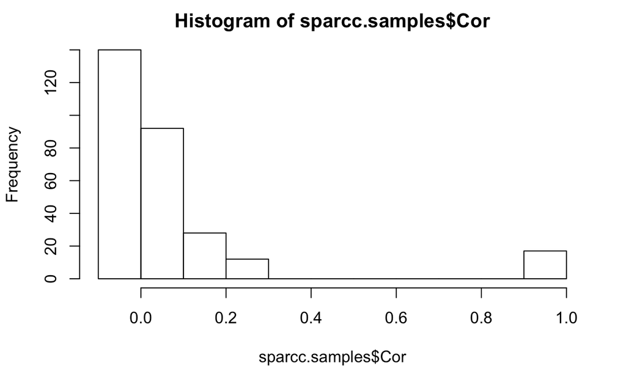

```r
row.names(sparcc.samples$Cor)<-row.names(sample_data(OsloFjord_phyloseq))
colnames(sparcc.samples$Cor)<-row.names(sample_data(OsloFjord_phyloseq))
hist(sparcc.samples$Cor)
```

```r
## Define threshold for SparCC correlation matrix for the graph
sparcc.graph.matrix <- abs(sparcc.samples$Cor) >= 0.1
#sparcc.graph.matrix
diag(sparcc.graph.matrix) <- 0
sparcc.graph.matrix <- Matrix(sparcc.graph.matrix, sparse=TRUE)

# Create igraph objects from the adjacency matrix
sparcc.graph <- adj2igraph(sparcc.graph.matrix, vertex.attr = list(name=row.names(otu_table(t(OsloFjord_phyloseq)))))
sparcc.graph
```

```
IGRAPH 7d8aba3 UNW- 17 20 --
+ attr: name (v/c), weight (e/n)
+ edges from 7d8aba3 (vertex names):
 [1] S01--S02 S01--S06 S01--S07 S01--S08 S03--S04 S03--S05 S03--S13 S04--S05
 [9] S04--S13 S05--S12 S05--S13 S06--S07 S06--S08 S07--S08 S07--S11 S08--S09
[17] S08--S11 S09--S10 S09--S11 S10--S11
```

- The graph has 17 vertices (node/otus) and 20 edges
- Attribute for the vertices (v/c) is `name` (i.e. the otu name)
- Attribute for the edges (e/n) is `weight` (i.e. the otu name)
- It is possible to add more attributes to either edges or vertices using `V(phyloseq_object)$new_attribute` and `E(phyloseq_object)$new_attribute`for the edges.

### Graph statistics

```r
# How connected are the nodes?
degree(sparcc.graph)
```

```
S01 S02 S03 S04 S05 S06 S07 S08 S09 S10 S11 S12 S13 S14 S15 S16 S17
  4   1   3   3   4   3   4   5   3   2   4   1   3   0   0   0   0
```

```r
#degree.distribution(sparcc.graph)

# extract the correaltion score for the graph
elist.sparcc<- summary(sparcc.graph.matrix*sparcc.samples$Cor)
elist.sparcc
```

```
17 x 17 sparse Matrix of class "dsCMatrix", with 20 entries
    i  j         x
1   1  2 0.1300646
2   3  4 0.1496484
3   3  5 0.1540979
4   4  5 0.2505773
5   1  6 0.1925274
6   1  7 0.2151646
7   6  7 0.1843485
8   1  8 0.1691653
9   6  8 0.1342070
10  7  8 0.2283061
11  8  9 0.2682336
12  9 10 0.1277423
13  7 11 0.1502505
14  8 11 0.1628445
15  9 11 0.1230069
16 10 11 0.2183136
17  5 12 0.1274766
18  3 13 0.1417801
19  4 13 0.1457467
20  5 13 0.2168190
```

```r
cat("\nNetwork stats\n", "Clustering coefficient: ", ClusteringCcoefficient <- transitivity(sparcc.graph), "\n")
```

```
Network stats
 Clustering coefficient:  0.66
```

```r
cat("Betweenness entrality: ", BetweennessCentrality<- edge_betweenness(sparcc.graph),"\n")
```

```
Betweenness entrality:  7 2 3.666667 6.333333 1 2 1 2 1 4 2 1.833333 3.166667 1.5 5 6 4 2.5 1.5 4.5
```

```r
cat("Average path length: ", AveragePathLength <- average.path.length(sparcc.graph),"\n")
```

```
Average path length:  1.631579
```

### Plotting

Plotting can be done in many different ways. Play with the settings to find somethign interesting

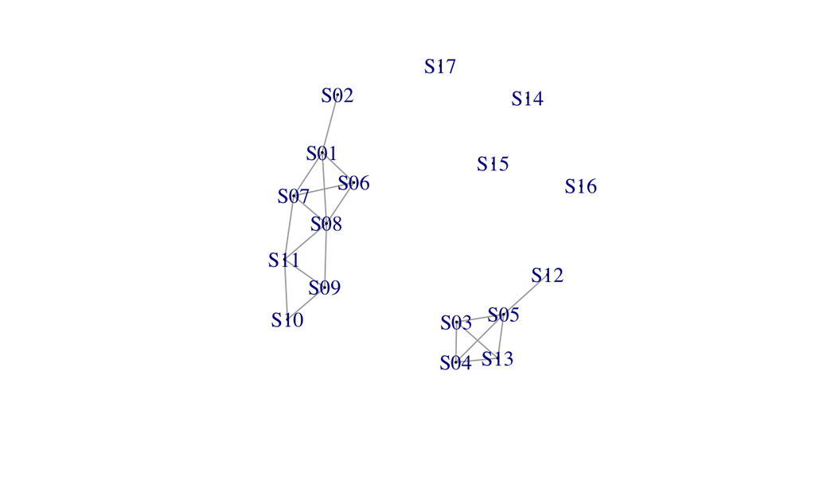

```r
plot(sparcc.graph,vertex.size=1)
```

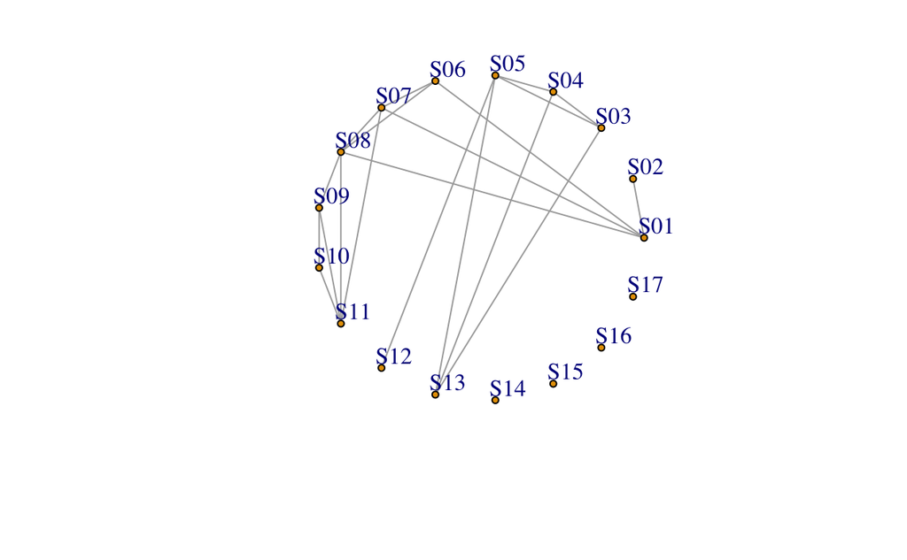

```r
plot(sparcc.graph,vertex.size=4, layout=layout_in_circle, vertex.label.dist=1.5)
```

```
attributes are not identical across measure variables; they will be dropped
```

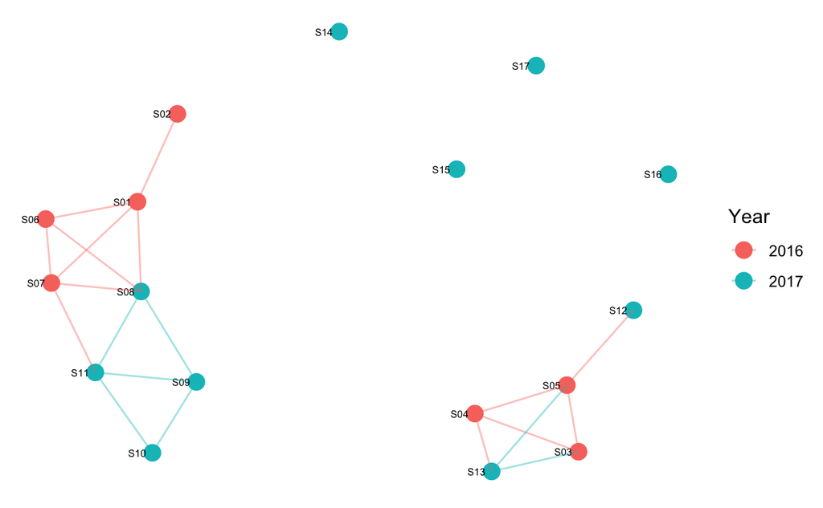

```r
#The plotting funciton in phyloseq takes graph and phyloseq objects as input
plot_network(sparcc.graph, OsloFjord_phyloseq, color="Year")
```

- Using the ctd-data can you create a factor that specifies months, and redo the network but with year as shape and months as colors? (hint use `sample_data(phyloseq_object)$new_variable` to add metadata to to an existingphyloseq object.

### Adding the correlation score as weights to the graph

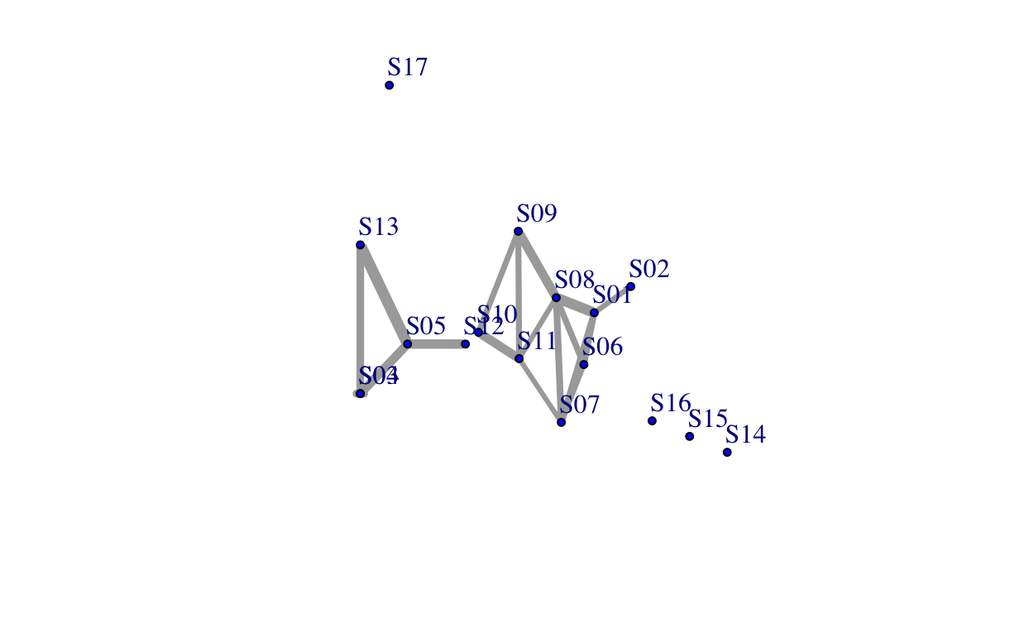

```r
elist.sparcc<- summary(sparcc.graph.matrix*sparcc.samples$Cor)
E(sparcc.graph)$weight<-elist.sparcc[,3]
E(sparcc.graph)$width <- 25*E(sparcc.graph)$weight
V(sparcc.graph)$color <- "blue"

#set.seed(666)
plot(sparcc.graph,vertex.size=4, vertex.label.dist=2, layout=layout_with_mds)
```

```r
# see help(layout)
```

- Maybe there are better ways of using the weights? For the graph above I simply multiplied the weight of the edge with a more or less randomly chosen number to make the lines visible.

# Networks for the OTUs.

The procedure is the same, but this time we need to transpose the otu table. Notice the function `t()` added around the phyloseq object. The sparcc inference will take a longer time for this matrix since there are many more otus than samples. The number of iterations is set low to save time, but should ideally be higher (20+).

```r
system.time({

sparcc.outs<- sparcc(otu_table(t(OsloFjord_phyloseq)), iter=10,inner_iter=20)
str(sparcc.outs)

})
```

```
Timing stopped at: 1.637 0.079 2.45
```

The sparcc object contains two list, the co-variance score and the correlation. In addition you should get boostrap and empirical p-values for the network. This takes some time, since the data is permutated and networks correlation scores are calculated may times over.

```
sparcc.outs.boot <- sparccboot(t(otu_table(OsloFjord_phyloseq)), R =100, ncpu=4)
sparcc.outs.pval <- pval.sparccboot(sparcc.outs.boot)
```

### Making a network of the correlation matrix

Turning the correlation values into a network requires a few steps.

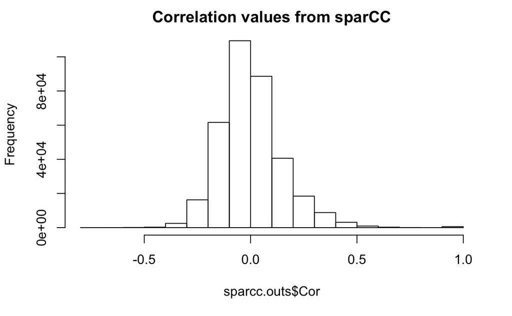

```r
row.names(sparcc.outs$Cor)<-row.names(otu_table(OsloFjord_phyloseq))
colnames(sparcc.outs$Cor)<-row.names(otu_table(OsloFjord_phyloseq))
hist(sparcc.outs$Cor, main = "Correlation values from sparCC")
```

```r
## Define threshold for SparCC correlation matrix for the graph
# Can be set much higher for the otus, than samples.
# Should ideally be seen in conjunction with p-vaues.
sparcc.otu.graph.matrix <- abs(sparcc.outs$Cor) >= 0.7
#head(sparcc.otu.graph.matrix)
diag(sparcc.otu.graph.matrix) <- 0
sparcc.otu.graph.matrix <- Matrix(sparcc.otu.graph.matrix, sparse=TRUE)

# Create igraph objects from the adjacency matrix
sparcc.outs.graph <- adj2igraph(sparcc.otu.graph.matrix, vertex.attr = list(name=row.names(otu_table(OsloFjord_phyloseq))))
sparcc.outs.graph
```

```
IGRAPH be90025 UNW- 593 29 --
+ attr: name (v/c), weight (e/n)
+ edges from be90025 (vertex names):
 [1] otu0001--otu0013 otu0006--otu0114 otu0007--otu0047 otu0009--otu0012
 [5] otu0009--otu0017 otu0011--otu0060 otu0013--otu0014 otu0016--otu0022
 [9] otu0016--otu0055 otu0018--otu0088 otu0018--otu0121 otu0019--otu0049
[13] otu0021--otu0038 otu0021--otu0131 otu0022--otu0059 otu0023--otu0037
[17] otu0024--otu0119 otu0025--otu0055 otu0025--otu0086 otu0026--otu0107
[21] otu0037--otu0041 otu0037--otu0219 otu0038--otu0131 otu0049--otu0064
[25] otu0055--otu0059 otu0057--otu0059 otu0059--otu0082 otu0059--otu0120
[29] otu0061--otu0069
```

### Some of the statistics for the graph

```r
# How connected are the nodes?
tail(sort(degree(sparcc.outs.graph)))
```

```
otu0038 otu0049 otu0131 otu0037 otu0055 otu0059
      2       2       2       3       3       5
```

```r
ave(degree(sparcc.outs.graph))[1]
```

```
   otu0001
0.09780776
```

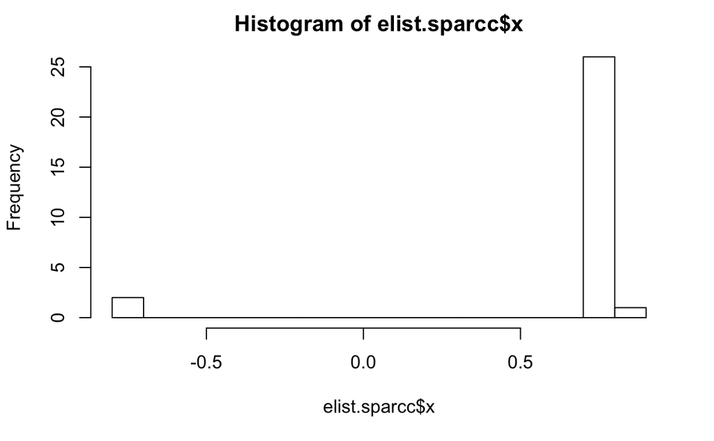

```r
#ectract the correaltion score for the graph
elist.sparcc<- summary(sparcc.otu.graph.matrix*sparcc.outs$Cor)
hist(elist.sparcc$x, breaks = 20)
```

### Plotting

Plotting otus will give amuc more clutterd graph than the samples, due to the high number elements (edges and nodes)

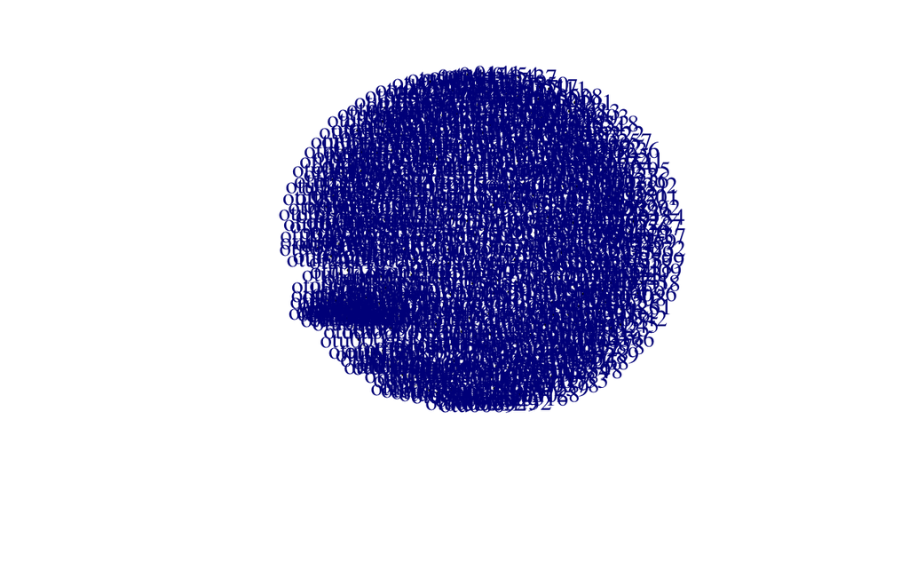

```r
plot(sparcc.outs.graph,vertex.size=1)
```

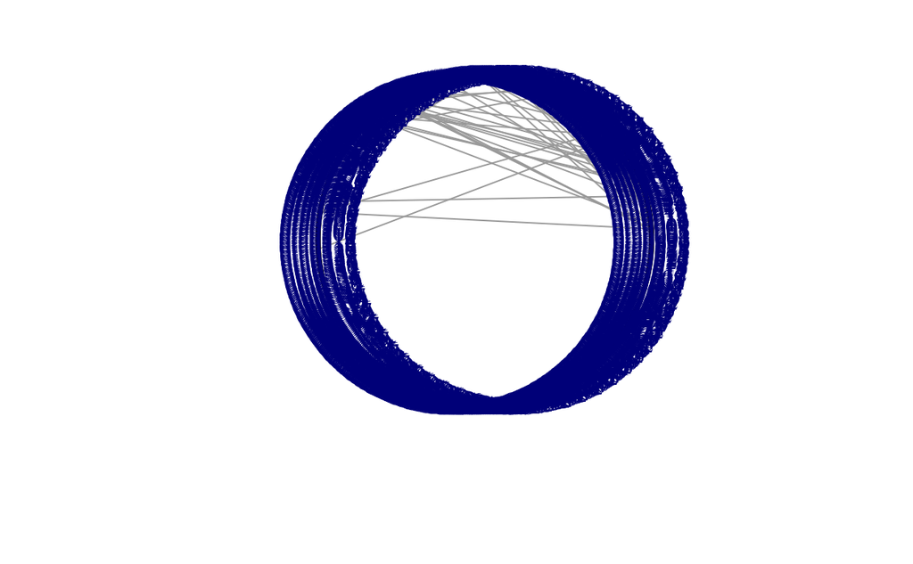

```r
plot(sparcc.outs.graph,vertex.size=0, layout=layout_in_circle, vertex.label=NULL)
```

```
attributes are not identical across measure variables; they will be dropped
```

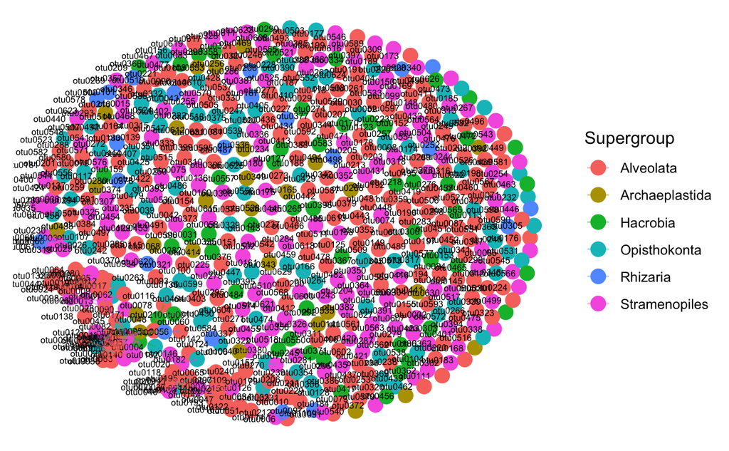

```r
#The phyloseq network plotter works better for these data
plot_network(sparcc.outs.graph, OsloFjord_phyloseq, type="taxa", color = "Supergroup")
```

- See if you can write a function that gives different color, or thickness to the edges depending on wheter they are positive or negative.  
  Removing nodes (otus) not connected to the rest of the graph makes it tidier

```
attributes are not identical across measure variables; they will be dropped
```

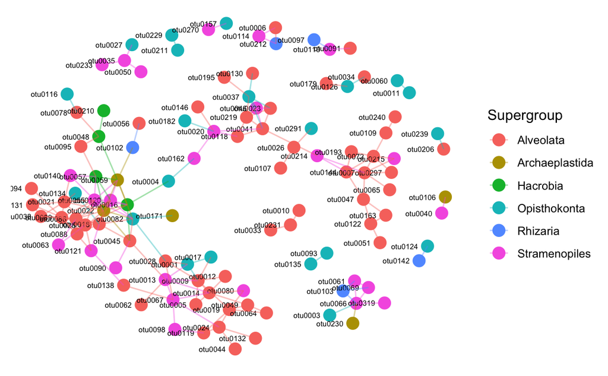

```r
plot_network(simplified.graph, OsloFjord_phyloseq,type= "taxa", color = "Supergroup")
```